# Восстановление золота из руды

### Рассчет эффективности rougher.output.recovery (MAE)

Эффективность обогащения рассчитывается по формуле:

$$\text{$Recovery = \dfrac{C \times (F-T)}{F \times (C-T)} \times 100\% $}$$

где:

- C — доля золота в концентрате после флотации/очистки;
- F — доля золота в сырье/концентрате до флотации/очистки;
- T — доля золота в отвальных хвостах после флотации/очистки.

```python
C = data_train['rougher.output.concentrate_au']
F = data_train['rougher.input.feed_au']
T = data_train['rougher.output.tail_au']
recovery = (C * (F-T)) / (F * (C - T)) * 100
```

```python
print("Средняя рассчитанная эффективность:", recovery.mean())
print("Средняя указанная эффективность:", data_train['rougher.output.recovery'].mean())
print()
print('MAE = {:.16f}'.format(mae(data_train['rougher.output.recovery'], recovery)))
```

```
Средняя рассчитанная эффективность: 82.52119968211305
Средняя указанная эффективность: 82.52119968211304

MAE = 0.0000000000000098
```

Средняя абсолютная ошибка мала - эффективность обогащения рассчитана правильно

### Анализ признаков, недоступных в тестовой выборке

```python
print('Столбцы, отсутствующие в "data_test"')
display(set(data_full.columns) - set(data_test.columns))
```

```
Столбцы, отсутствующие в "data_test"
```

```
{'final.output.concentrate_ag',
 'final.output.concentrate_au',
 'final.output.concentrate_pb',
 'final.output.concentrate_sol',
 'final.output.recovery',
 'final.output.tail_ag',
 'final.output.tail_au',
 'final.output.tail_pb',
 'final.output.tail_sol',
 'primary_cleaner.output.concentrate_ag',
 'primary_cleaner.output.concentrate_au',
 'primary_cleaner.output.concentrate_pb',
 'primary_cleaner.output.concentrate_sol',
 'primary_cleaner.output.tail_ag',
 'primary_cleaner.output.tail_au',
 'primary_cleaner.output.tail_pb',
 'primary_cleaner.output.tail_sol',
 'rougher.calculation.au_pb_ratio',
 'rougher.calculation.floatbank10_sulfate_to_au_feed',
 'rougher.calculation.floatbank11_sulfate_to_au_feed',
 'rougher.calculation.sulfate_to_au_concentrate',
 'rougher.output.concentrate_ag',
 'rougher.output.concentrate_au',
 'rougher.output.concentrate_pb',
 'rougher.output.concentrate_sol',
 'rougher.output.recovery',
 'rougher.output.tail_ag',
 'rougher.output.tail_au',
 'rougher.output.tail_pb',
 'rougher.output.tail_sol',
 'secondary_cleaner.output.tail_ag',
 'secondary_cleaner.output.tail_au',
 'secondary_cleaner.output.tail_pb',
 'secondary_cleaner.output.tail_sol'}
```

- "rougher.output.recovery" и "final.output.recovery" - целевые признаки для нашей модели
- Остальные отсутствующие признаки содержат информацию:
  - Либо о параметрах продукта после всех этапов флотации и очисток
  - Либо расчетные характеристики
- Данные признаки не нужны для тестирования нашей модели

### Предобработка данных

Судя по признаку "date" данные обновляются каждый час. Соседние объекты в каждом признаке примерно одинаковы, таким образом можем заполнить пропуски методом "ffill" (нулевые значения заменяются данными из предыдущеей строки).

Заполним пропуски в обучающей и тестовой выборках.

Исходные данные оставим без изменений.

```python
for i in datas:
    print('Количество пропусков до замены в "{}": {} шт.'.format(i, datas[i].isna().sum().sum()))
```

```
Количество пропусков до замены в "Обучающая выборка": 3050 шт.
Количество пропусков до замены в "Тестовая выборка": 375 шт.
Количество пропусков до замены в "Исходные данные": 4481 шт.
```

```python
data_train = data_train.ffill().bfill()
data_test = data_test.ffill().bfill()
```

```python
datas = {'Обучающая выборка' : data_train, 'Тестовая выборка' : data_test, 'Исходные данные' : data_full}
for i in datas:
    print('Количество пропусков после замены в "{}": {} шт.'.format(i, datas[i].isna().sum().sum()))
```

```
Количество пропусков после замены в "Обучающая выборка": 0 шт.
Количество пропусков после замены в "Тестовая выборка": 0 шт.
Количество пропусков после замены в "Исходные данные": 4481 шт.
```

## Анализ данных

### Концентрация металлов (Au, Ag, Pb) на различных этапах очистки

```python
def concentrate_hist(chem_element, title):
    x1 = data_full[f'rougher.input.feed_{chem_element}'].ffill().bfill()
    x2 = data_full[f'rougher.output.concentrate_{chem_element}'].ffill().bfill()
    x3 = data_full[f'primary_cleaner.output.concentrate_{chem_element}'].ffill().bfill()
    x4 = data_full[f'final.output.concentrate_{chem_element}'].ffill().bfill()

    f, ax = plt.subplots(figsize=(15, 7))

    sns.histplot(x1, fill=False, label="Сырье", kde=True);
    sns.histplot(x2, fill=False, label="Черновой концентрат", kde=True);
    sns.histplot(x3, fill=False, label="Первичная очистка", kde=True);
    sns.histplot(x4, fill=False, label="Финальный концентрат", kde=True);

    plt.legend();

    plt.title(label=f'Концентрация {title} на различных этапах очистки', fontsize=15)
    plt.xlabel('Концентрация')
    plt.ylabel(' ')
```

#### Золото

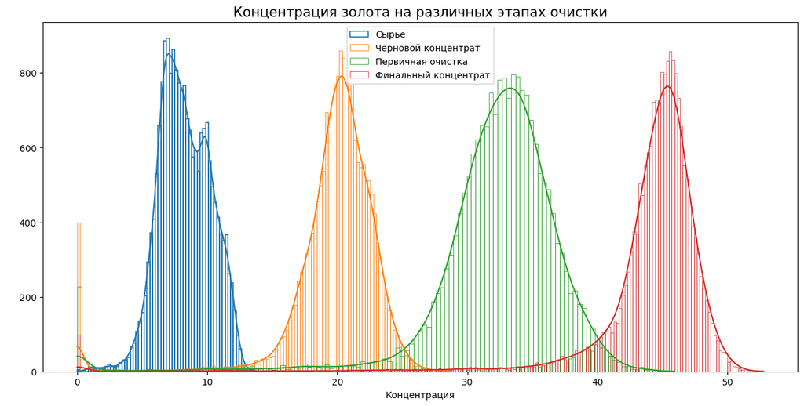

```python
concentrate_hist('au', 'золота')
```

Концентрация золота увеличивается после каждого этапа очистки

#### Серебро

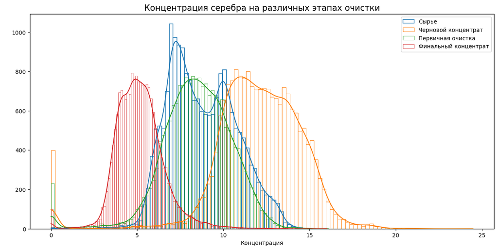

```python
concentrate_hist('ag', 'серебра')
```

Концентрация серебра увеличивается после флотации и резко уменьшается после второго этапа очистки

#### Свинец

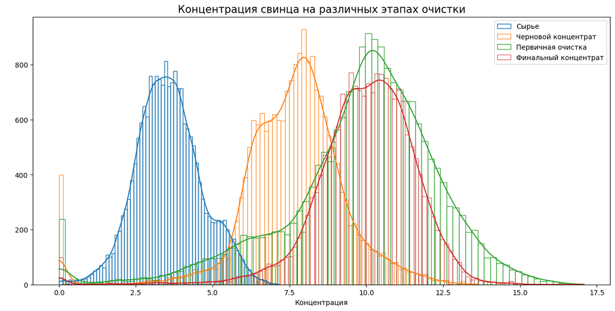

```python
concentrate_hist('pb', 'свинца')
```

Концентрация свинца значительно увеличивается после флотации и незначительно увеличивается на оставшихся этапах

### Сравнение распределения размеров гранул сырья на обучающей и тестовой выборках

```python
def granules_hist(stage, title):
    x1 = data_train[f'{stage}.input.feed_size']
    x2 = data_test[f'{stage}.input.feed_size']

    f, ax = plt.subplots(figsize=(15, 7))

    sns.histplot(x1, fill=False, label="Обучающая выборка", kde=True);
    sns.histplot(x2, fill=False, label="Тестовая выборка", kde=True);

    plt.legend();

    plt.title(label=f'Распределение размеров гранул сырья для {title}', fontsize=15)
    plt.xlabel('Размер гранул')
    plt.ylabel(' ')
```

#### Этап флотации

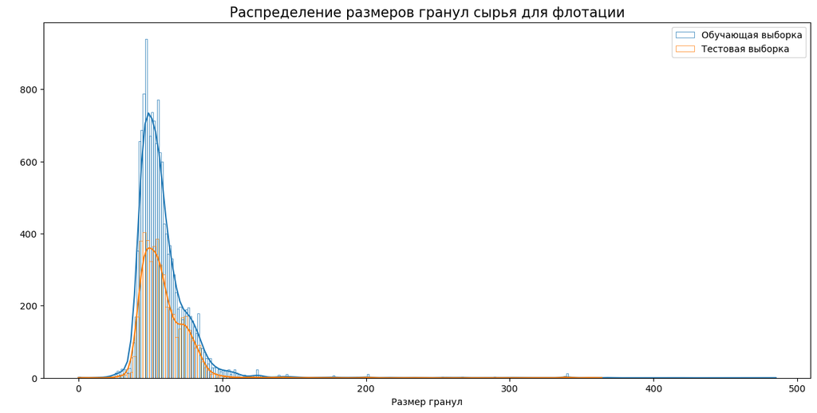

```python
granules_hist('rougher', 'флотации')
```

Распределение размеров гранул примерно одинаково на обеих выборках

#### Этап очистки

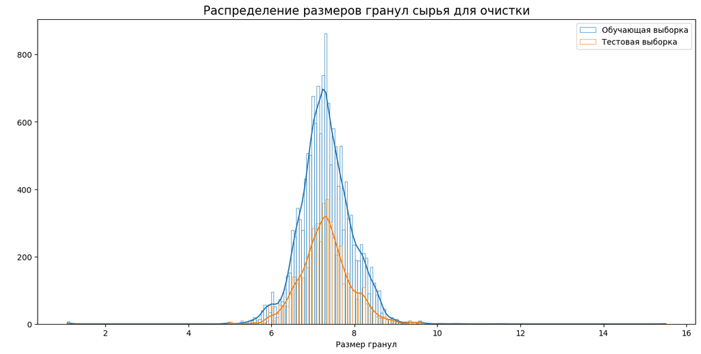

```python
granules_hist('primary_cleaner', 'очистки')
```

Распределение размеров гранул примерно одинаково на обеих выборках

### Исследование суммарной концентрации всех веществ на разных стадиях

```python
stages = ['rougher.input.feed_', 'rougher.output.concentrate_', 'final.output.concentrate_']
chem_element = ['au', 'ag', 'pb', 'sol']

for stage in stages:
    data_full[stage + 'sum'] = 0
    for el in chem_element:
        data_full[stage + 'sum'] += data_full[stage + el]
```

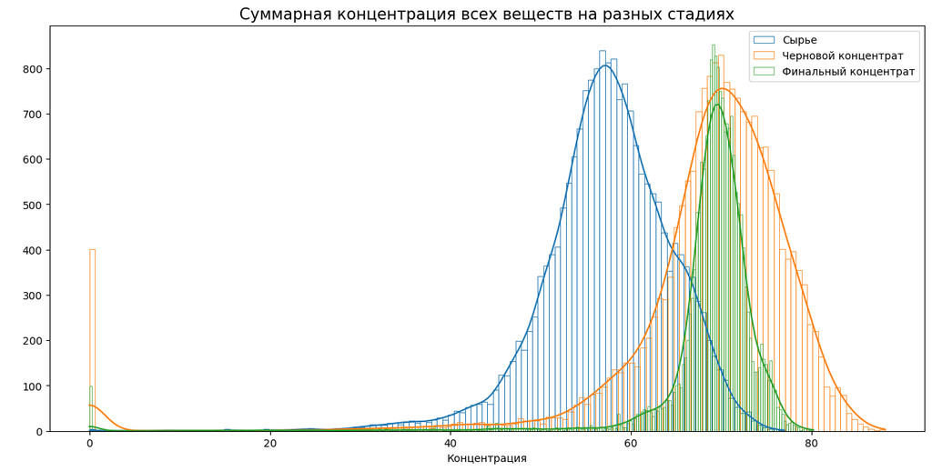

```python
x1 = data_full['rougher.input.feed_sum'].ffill().bfill()
x2 = data_full['rougher.output.concentrate_sum'].ffill().bfill()
x3 = data_full['final.output.concentrate_sum'].ffill().bfill()

f, ax = plt.subplots(figsize=(15, 7))

sns.histplot(x1, fill=False, label="Сырье", kde=True);
sns.histplot(x2, fill=False, label="Черновой концентрат", kde=True);
sns.histplot(x3, fill=False, label="Финальный концентрат", kde=True);

plt.legend();

plt.title(label='Суммарная концентрация всех веществ на разных стадиях', fontsize=15);
plt.xlabel('Концентрация');
plt.ylabel(' ');
```

- Суммарная концентрация всех веществ после этапа флотации увеличивается
- После этапов очистки сокращается интервал распределения
- В данных присутствуют аномалии в виде суммарной концентрации веществ равной нулю
  - Удалим аномалии из исходных данных и обеих выборок

```python
anomaly_date = data_full['date'][(data_full['rougher.input.feed_sum']==0)|(
    data_full['rougher.output.concentrate_sum']==0)|(data_full['final.output.concentrate_sum']==0)]

print('Общее количество аномалий:', anomaly_date.count())
print()

datas = {'Обучающая выборка' : data_train, 'Тестовая выборка' : data_test, 'Исходные данные' : data_full}
for i in datas:
    print('Количество аномалий в {} - {} шт.'.format(i, datas[i]['date'][datas[i]['date'].isin(anomaly_date)].count()))

data_train = data_train[~data_train['date'].isin(anomaly_date)]
data_test = data_test[~data_test['date'].isin(anomaly_date)]
data_full = data_full[~data_full['date'].isin(anomaly_date)]

print()

datas = {'Обучающая выборка' : data_train, 'Тестовая выборка' : data_test, 'Исходные данные' : data_full}
for i in datas:
    print('Количество аномалий в {} после удаления - {} шт.'.format(
        i, datas[i]['date'][datas[i]['date'].isin(anomaly_date)].count()))
```

```
Общее количество аномалий: 490

Количество аномалий в Обучающая выборка - 490 шт.
Количество аномалий в Тестовая выборка - 0 шт.
Количество аномалий в Исходные данные - 490 шт.

Количество аномалий в Обучающая выборка после удаления - 0 шт.
Количество аномалий в Тестовая выборка после удаления - 0 шт.
Количество аномалий в Исходные данные после удаления - 0 шт.
```

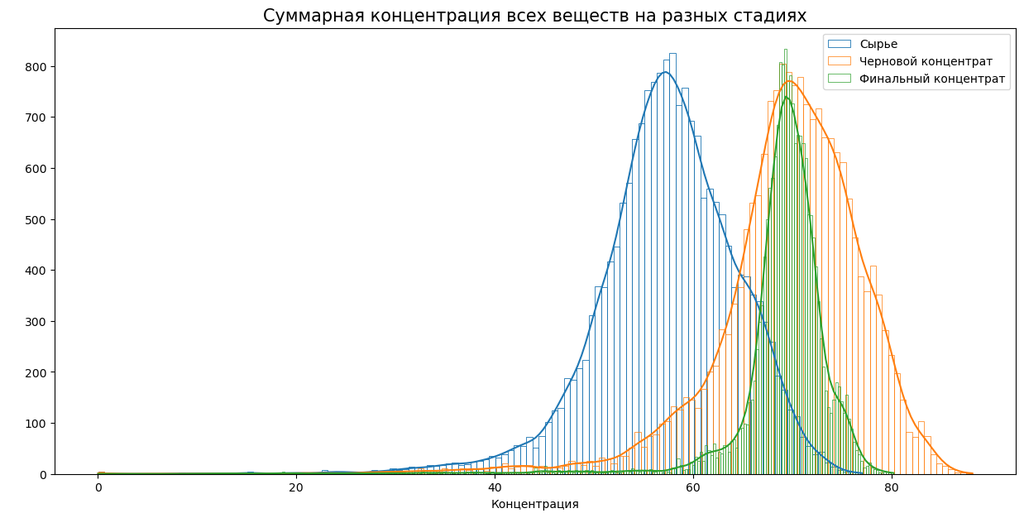

```python
x1 = data_full['rougher.input.feed_sum'].ffill().bfill()
x2 = data_full['rougher.output.concentrate_sum'].ffill().bfill()
x3 = data_full['final.output.concentrate_sum'].ffill().bfill()

f, ax = plt.subplots(figsize=(15, 7))

sns.histplot(x1, fill=False, label="Сырье", kde=True);
sns.histplot(x2, fill=False, label="Черновой концентрат", kde=True);
sns.histplot(x3, fill=False, label="Финальный концентрат", kde=True);

plt.legend();

plt.title(label='Суммарная концентрация всех веществ на разных стадиях', fontsize=15);
plt.xlabel('Концентрация');
plt.ylabel(' ');
```

Аномалии в данных отсутствуют

## Модель

### Функция для вычисления итоговой sMAPE

Для решения задачи используем метрику качества — sMAPE (англ. Symmetric Mean Absolute Percentage Error, «симметричное среднее абсолютное процентное отклонение»).

Метрика sMAPE рассчитывается по формуле:

$$\text{$sMAPE = \dfrac{1}{N}\sum_{i=1}^{N} \dfrac{|y_i - \hat y_i|}{(|y_i| + |\hat y_i|)\div 2} \times 100\% $}$$

где:

- $y_i$ — Значение целевого признака для объекта с порядковым номером i в выборке, на которой измеряется качество
- $\hat y_i$ — Значение предсказания для объекта с порядковым номером i, например, в тестовой выборке
- N — Количество объектов в выборке
- $\sum_{i=1}^{N}$ — Суммирование по всем объектам выборки (i меняется от 1 до N)

Нашей модели нужно спрогнозировать сразу две величины:

1. Эффективность обогащения чернового концентрата (**rougher.output.recovery**)
2. Эффективность обогащения финального концентрата (**final.output.recovery**)

Итоговая метрика складывается из двух величин:

$$\text{${Итоговое}\:{sMAPE} = 25\% \times sMAPE(rougher) + 75\% \times sMAPE(final)$}$$

```python
def smape(target, pred):
    smape = abs(target - pred) / ((abs(target) + abs(pred)) / 2) * 100
    smape = smape.fillna(value=0)
    smape = sum(smape) / len(smape)
    return smape

def smape_final(smape_rougher, smape_final):
    return 0.25 * smape_rougher + 0.75 * smape_final

smape_score = make_scorer(smape, greater_is_better=False)
```

### Подготовка данных для обучения

```python
target_rougher_test = pd.merge(data_test, data_full, how='left', on=['date'])
target_rougher_test = target_rougher_test['rougher.output.recovery']
target_final_test = pd.merge(data_test, data_full, how='left', on=['date'])
target_final_test = target_final_test['final.output.recovery']

data_test = data_test.drop(['date'], axis=1)

col = data_test.columns
features = data_train[col]
target_rougher = data_train['rougher.output.recovery']
target_final = data_train['final.output.recovery']

features_list = {'features' : features}
targets_list = {'target_rougher' : target_rougher, 'target_final' : target_final}

print('Вспомогательные признаки:')
print()
for i in features_list:
    sh = features_list[i].shape
    psh = sh[0]/len(data_train)
    print('{} - Объектов: {} шт., признаков: {} шт. - {:.2%}'.format(i, sh[0], sh[1], psh))

print()

print('Целевые признаки:')
print()
for i in targets_list:
    sh = targets_list[i].shape
    psh = sh[0]/len(data_train)
    print('{} - Объектов: {} шт. - {:.2%}'.format(i, sh[0], psh))
```

```
Вспомогательные признаки:

features - Объектов: 14089 шт., признаков: 52 шт. - 100.00%

Целевые признаки:

target_rougher - Объектов: 14089 шт. - 100.00%
target_final - Объектов: 14089 шт. - 100.00%
```

Стандартизируем численные признаки в выборках, так как в данных присутствуют значения в разных масштабах

```python
pd.options.mode.chained_assignment = None

features_list = {'features' : features, 'data_test' : data_test}

scaler = StandardScaler()
scaler.fit(features[col])

for i in features_list:
    features_list[i][col] = scaler.transform(features_list[i][col])
    print('{}:'.format(i))
    display(features_list[i].sample(5, random_state=r_state))
    print()
```

```
features:
```

|  | rougher.input.feed_au | rougher.input.feed_ag | rougher.input.feed_pb | rougher.input.feed_sol | rougher.input.feed_rate | rougher.input.feed_size | rougher.input.floatbank10_sulfate | rougher.input.floatbank10_xanthate | rougher.state.floatbank10_a_air | rougher.state.floatbank10_a_level | ... | secondary_cleaner.state.floatbank4_a_air | secondary_cleaner.state.floatbank4_a_level | secondary_cleaner.state.floatbank4_b_air | secondary_cleaner.state.floatbank4_b_level | secondary_cleaner.state.floatbank5_a_air | secondary_cleaner.state.floatbank5_a_level | secondary_cleaner.state.floatbank5_b_air | secondary_cleaner.state.floatbank5_b_level | secondary_cleaner.state.floatbank6_a_air | secondary_cleaner.state.floatbank6_a_level |
| --- | --- | --- | --- | --- | --- | --- | --- | --- | --- | --- | --- | --- | --- | --- | --- | --- | --- | --- | --- | --- | --- |
| 4471 | 1.216444 | 0.193767 | -0.049684 | -0.272741 | -0.368005 | -0.606031 | 0.772211 | -0.013842 | -0.651206 | -1.260238 | ... | 0.243632 | -0.299017 | 0.434781 | -0.573802 | 0.286803 | -0.337275 | 0.385466 | -0.354252 | 1.090761 | 0.142823 |
| 8621 | -0.654844 | -1.100730 | -0.354170 | -2.171698 | -0.050536 | -0.227404 | 1.357899 | -0.014934 | -0.636811 | 0.842090 | ... | 0.624327 | -0.313718 | 0.040554 | 1.215122 | 0.477301 | -0.351321 | 0.185429 | -0.366920 | -0.730077 | 0.152954 |
| 5910 | 0.712961 | 0.788081 | 0.145395 | 0.481891 | -0.176740 | -0.567061 | 0.478408 | -0.015702 | -0.635469 | -1.263740 | ... | -0.532050 | -0.368413 | 0.237466 | -0.611805 | -0.460982 | -0.424373 | 0.562217 | -0.372989 | 0.173458 | -2.581115 |
| 7012 | 0.629188 | 0.739351 | 0.829257 | 0.665510 | -0.311252 | -0.252994 | 0.185367 | -0.452344 | 1.213718 | 0.842780 | ... | 1.202851 | 1.683064 | 1.692547 | 0.898107 | 1.553194 | 1.011185 | 1.228930 | 0.932348 | 1.082008 | 0.077814 |
| 8363 | -1.240525 | -0.985350 | -0.698040 | -0.159647 | 0.332162 | -0.345366 | 1.357748 | -1.233457 | -0.642571 | 0.843225 | ... | -0.145742 | -0.309033 | -0.376701 | 1.206377 | 0.472073 | -0.367515 | 0.183132 | -0.377283 | -0.733272 | 0.151088 |

5 rows × 52 columns

```
data_test:
```

|  | rougher.input.feed_au | rougher.input.feed_ag | rougher.input.feed_pb | rougher.input.feed_sol | rougher.input.feed_rate | rougher.input.feed_size | rougher.input.floatbank10_sulfate | rougher.input.floatbank10_xanthate | rougher.state.floatbank10_a_air | rougher.state.floatbank10_a_level | ... | secondary_cleaner.state.floatbank4_a_air | secondary_cleaner.state.floatbank4_a_level | secondary_cleaner.state.floatbank4_b_air | secondary_cleaner.state.floatbank4_b_level | secondary_cleaner.state.floatbank5_a_air | secondary_cleaner.state.floatbank5_a_level | secondary_cleaner.state.floatbank5_b_air | secondary_cleaner.state.floatbank5_b_level | secondary_cleaner.state.floatbank6_a_air | secondary_cleaner.state.floatbank6_a_level |
| --- | --- | --- | --- | --- | --- | --- | --- | --- | --- | --- | --- | --- | --- | --- | --- | --- | --- | --- | --- | --- | --- |
| 3781 | 1.353402 | 0.982176 | 0.315215 | -0.854309 | -0.685387 | -0.675210 | -0.694837 | 0.029063 | -0.635241 | -1.262557 | ... | -2.076551 | -0.312918 | -2.045716 | -0.594127 | -1.376264 | -0.365495 | -1.727896 | -0.369707 | 0.170859 | -2.535000 |
| 716 | -2.418251 | -1.125227 | -2.898236 | 0.815251 | 0.119995 | 0.461862 | -2.229231 | -0.101639 | 0.605945 | 0.843558 | ... | 2.161364 | -0.343397 | 1.072303 | -0.586821 | 1.032829 | -0.363060 | 0.658257 | -0.357746 | 0.174335 | 0.158687 |
| 4597 | -0.284068 | -0.661772 | -1.156902 | 0.244627 | 0.274791 | -0.491283 | -0.733426 | 1.238929 | -0.637875 | -1.263462 | ... | -1.304688 | -0.302430 | -0.604095 | -0.598878 | -0.620244 | -0.364722 | -0.371996 | -0.363644 | 0.176599 | 0.135719 |
| 4178 | -1.408210 | -1.041203 | -0.673409 | -2.445829 | -0.771668 | -0.569547 | -0.404565 | -1.499784 | -0.635945 | -0.205191 | ... | -1.669044 | -0.319784 | -1.433996 | -0.905163 | -1.365451 | -0.462218 | -1.150198 | -0.384696 | -0.188117 | 0.029687 |
| 3547 | 0.080532 | -0.553554 | 0.412291 | -1.786583 | -0.749856 | -0.831343 | 0.771006 | -0.452420 | -0.639621 | -1.264644 | ... | 0.240798 | -0.321072 | 0.442089 | -0.599558 | 0.286814 | -0.353476 | 0.377475 | -0.361705 | 0.537313 | 0.126299 |

5 rows × 52 columns

### Поиск лучшей модели

#### Константная модель

```python
smape_rougher_const = smape(target_rougher, target_rougher.mean())
smape_final_const = smape(target_final, target_final.mean())
score_const = smape_final(smape_rougher_const, smape_final_const)
print('Итоговое sMAPE константной модели:', score_const)
```

```
Итоговое sMAPE константной модели: 9.109564280483204
```

#### Decision Tree (Дерево решений)

```python
best_score_DT = 1000
best_depth_DT = 0
for depth in tqdm(range(1,21)):
    model_decision_tree = DecisionTreeRegressor(random_state=r_state, max_depth=depth)
    smape_r = abs(cross_val_score(model_decision_tree, features, target_rougher, cv=5, scoring=smape_score))
    smape_f = abs(cross_val_score(model_decision_tree, features, target_final, cv=5, scoring=smape_score))
    final_score = smape_final(smape_r, smape_f).mean()
    if final_score < best_score_DT:
        best_score_DT = final_score
        best_depth_DT = depth

print()
print('Лучший результат:')
print('Глубина =', best_depth_DT, ', Итоговое sMAPE =', best_score_DT)
```

```
Лучший результат:
Глубина = 2 , Итоговое sMAPE = 8.779830899334977
```

#### Random Forest (Случайный лес)

```python
best_score_RF = 1000
best_est_RF = 0
best_depth_RF = 0

for est in range(1, 101, 20):
    for depth in tqdm(range(1, 21, 5)):
        model_random_forest = RandomForestRegressor(random_state=r_state, n_estimators=est, max_depth=depth)
        smape_r = abs(cross_val_score(model_random_forest, features, target_rougher, cv=5, scoring=smape_score))
        smape_f = abs(cross_val_score(model_random_forest, features, target_final, cv=5, scoring=smape_score))
        final_score = smape_final(smape_r, smape_f).mean()
        if final_score < best_score_RF:
            best_score_RF = final_score
            best_est_RF = est
            best_depth_RF = depth

print()
print('Лучший результат:')
print('Количество деревьев =', best_est_RF,', глубина =', best_depth_RF, ', Итоговое sMAPE =', best_score_RF)
```

```
Лучший результат:
Количество деревьев = 61 , глубина = 6 , Итоговое sMAPE = 8.689526885467895
```

#### Linear Regression (Линейная регрессия)

```python
best_score_LR = 1000
best_fit_intercept_LR = ''
fit_intercept = ['True', 'False']

for fit in tqdm(fit_intercept):
    model_linear_regression = LinearRegression(fit_intercept=fit_intercept)
    smape_r = abs(cross_val_score(model_linear_regression, features, target_rougher, cv=5, scoring=smape_score))
    smape_f = abs(cross_val_score(model_linear_regression, features, target_final, cv=5, scoring=smape_score))
    final_score = smape_final(smape_r, smape_f).mean()
    if final_score < best_score_LR:
        best_score_LR = final_score
        best_fit_intercept_LR = fit

print()
print('Лучший результат:')
print('fit_intercept =', best_fit_intercept_LR, ', Итоговое sMAPE =', best_score_LR)
```

```
Лучший результат:
fit_intercept = True , Итоговое sMAPE = 8.90180956927614
```

#### Определим лучшую модель

```python
max_score = best_score_DT
if max_score > best_score_RF:
    max_score = best_score_RF
if max_score > best_score_LR:
    max_score = best_score_LR

if max_score == best_score_DT:
    print('Лучшая модель: Decision Tree (Дерево решений), с гиперпараметром max_depth =', best_depth_DT)
if max_score == best_score_RF:
    print('Лучшая модель: Random Forest (Случайный лес), с гиперпараметрами n_estimators =', best_est_RF,
      ', max_depth =', best_depth_RF)
if max_score == best_score_LR:
    print('Лучшая модель: Linear Regression (Линейная регрессия), с гиперпараметрами fit_intercept =', best_fit_intercept_LR)
print('Итоговое sMAPE =', max_score)

if max_score < score_const:
    print('Итоговое sMAPE модели меньше константной, модель подходит для обучения')
else:
    print('Итоговое sMAPE модели больше константной, модель не подходит для обучения')
```

```
Лучшая модель: Random Forest (Случайный лес), с гиперпараметрами n_estimators = 61 , max_depth = 6
Итоговое sMAPE = 8.689526885467895
Итоговое sMAPE модели меньше константной, модель подходит для обучения
```

### Тестирование модели

```python
model = RandomForestRegressor(random_state=r_state, n_estimators=best_est_RF, max_depth=best_depth_RF)
model.fit(features, target_rougher)
predictions_rougher_test = pd.Series(model.predict(data_test))
model.fit(features, target_final)
predictions_final_test = pd.Series(model.predict(data_test))
smape_r = abs(smape(target_rougher_test, predictions_rougher_test))
smape_f = abs(smape(target_final_test, predictions_final_test))
final_score = smape_final(smape_r, smape_f)

print('sMAPE на тестовой выборке:', final_score)
```

```
sMAPE на тестовой выборке: 6.334999771849558
```

- sMAPE на тестовой выборке меньше sMAPE лучшей модели
- sMAPE на тестовой выборке меньше константной
- Модель справилась с обучением